# Basic Python

## Lesson 1: Expressions, variables and built-in functions

### Expressions

An expression describes a computation. Python evaluates expressions and generates a value. We say that expressions "evaluate to" their result.

```
2019
```

```
2019
```

Python's arithmetic operators allows you to use a Python command line or Jupyter notebook cell as a "calculator"

```
2000 + 19
```

```
2019
```

```
2000 - 19
```

```
1981
```

Multiplication is done with an asterisk `*`

```
1 * 2 * (3 * 4)
```

```
24
```

Normal or "true" division is done with `/`. This operation will always return a `float`

```
10 / 2
```

```
5.0
```

Python has two other division operators. "Floor" division `//`, which returns the division rounded down to the lowest integer, and the `modulo` operator `%`, which returns the remainder of a division after substracting the next lowest integer. These are easier to understand by example:

```
10 // 6
```

```
1
```

```
10 % 6
```

```
4
```

```
6 // 2
```

```
3
```

```
6 % 3
```

```
0
```

To take an exponent, use two asterisks `**` (NOT `^`)

```
2 ** 3
```

```
8
```

### Variables

* Variables are names for values. * In Python the = symbol assigns the value on the right to the name on the left. * The variable is created when a value is assigned to it. * Every variable has a `type` that describes what sort of data it contains. Some of the most common types are `int` (integer), `float` (floating point number), and `string` (text) * Unlike many other languages, in Python you do not have to specify the type when you create a variable. Python infers the data type based on the context. This is called 'duck typing'.

`int` variables are simply numbers. Let's assign 27 to a variable 'age'. If the variable `age` does not already exist, this **assignment expression** will create it

```
age = 27
```

You can find the type of a variable using the `type()` function. Let's examine the type of `age`.

```
type(age)
```

```
int
```

`float` variables are created by adding a decimal point to a number. Let's redefine `age` as 27.0 and check the type

```
age = 27.0
```

```
type(age)
```

```
float
```

```
first_name = "Ryan"
```

```
type(first_name)
```

```
str
```

Note that it's possible to create a `string` that contains only numbers

```
age = "27"
```

```
type(age)
```

```
str
```

In the Jupyter notebook, variable names are preserved between cells. In more formal language, the *namespace of a notebook is preserved* unless the kernel is reset, which resets all of the variable names. You can see this if you execute the following cells out of sequence. Try it out. Also try resetting the kernel and executing just the latter half.

```
age = 42
```

```
age
```

```
42
```

Assigning a new value to an existing variable will *replace* the value of that variable

```
age = 29
```

```
age
```

```
29
```

### Built-in functions

Now that we understand how Python and Jupyter handle variables, let's talk about [built-in functions](https://docs.python.org/3/library/functions.html). These functions are available by default without issuing any special instructions. One such function is `type`, which we've already used.

Functions are called using the function name and parentheses, which enclose the **function arguments**. In the example below, `print` is the function, and the string `"Hello world!"` is the argument.

```
print("Hello world!")
```

```
Hello world!
```

`print` can accept multiple arguments, separate by commas, and will combine them together to generate its output, like this:

```
print("Age is", age, "years")
```

```
Age is 29 years
```

One of the most important things you can know when learning programming is where to access help on the things you're trying to use. There are a number of ways to access information on a function. Three of the easiest ways in Jupyter are

1. Place your cursor inside the name of any function, and press SHIFT+TAB. This will open a small box with function information, which can be expanded by pressing tab again.
2. Use the built-in `help` function, where the argument to `help` is the name of the function you want to know more about.
3. Type the name of the function followed by `?`, which will show the functions documentation or 'docstring'

#### Finding help

```
## click your cursor inside 'print' and press SHIFT+TAB
print("this is cool")
```

```
this is cool
```

```
help(print)
```

```
Help on built-in function print in module builtins:

print(...)
    print(value, ..., sep=' ', end='\n', file=sys.stdout, flush=False)

    Prints the values to a stream, or to sys.stdout by default.
    Optional keyword arguments:
    file:  a file-like object (stream); defaults to the current sys.stdout.
    sep:   string inserted between values, default a space.
    end:   string appended after the last value, default a newline.
    flush: whether to forcibly flush the stream.
```

```
print?
```

#### Importing other modules and functions

To get a function that's not built in to Python, we use the `import` statement. In this example, we're going to import a module called `math` that contains a number of functions that can be accessed by using `math.FUNCTION_NAME_HERE`.

```
import math
```

```
math.exp(2)
```

```
7.38905609893065
```

```
print("Exponent of 2:", math.exp(2))
print("Sine of 3.1415:", math.sin(3.1415))
```

```
Exponent of 2: 7.38905609893065
Sine of 3.1415: 9.265358966049024e-05
```

The Standard library includes a number of modules that come pre-installed with the python programming language itself, which is summarized in this [documentation](https://docs.python.org/3/library/index.html). Python's real power, however, comes in how extensible it is. Python has an ecosystem of external libraries that provide special functions for many different tasks. Three of the most common external libraries in python are:

- numpy - for efficient numerical array manipulation and operation
- scipy - for a number of tools related to scientific computing
- matplotlib - for plotting data and creating figures

Let's use some functions from numpy and matplotlib to create a plot

```
import numpy as np
from matplotlib import pyplot
inflammation = np.loadtxt("inflammation-01.csv", delimiter=',')
%matplotlib inline

average = np.average(inflammation, axis=0)
pyplot.plot(average)
```

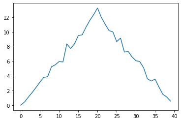

## Lesson 2: Lists and Strings

### A list stores many values in a single structure.

- A `list` stores many values together.
- Contained within square brackets `[...]`.
- Values separated by commas `,`.
- Use `len` to find out how many values are in a list.

```
pressures  = [0.273, 0.275, 0.277, 0.275, 0.276]
print('pressures:', pressures)
```

```
pressures: [0.273, 0.275, 0.277, 0.275, 0.276]
```

### Use the built-in function `len` to find the length of a list

```
len(pressures)
```

```
5
```

### Lists may be *heterogeneous*

- Values can have different types

```
goals = [1, 'Create lists.', 2, 'Extract items from lists.',
         3, 'Modify lists.']
```

### Index and slice to get information out of a string/list

- Locations are numbered from 0 rather than 1
- Negative indices count backward from the end of the string
- Slices *include* the lower bound but *exclude* the upper bound, so `(upper - lower)` is the slice's length

```
numbers = ["one", "two", "three", "four", "five"]
```

```
print('first element:', numbers[0])
print('last element:', numbers[-1])
print('middle elemnets:', numbers[2:5])
```

```
first element: one
last element: five
middle elemnets: ['three', 'four', 'five']
```

Indexing beyond the end of a collection is an error

```
# NBVAL_RAISES_EXCEPTION
## This code will fail
print('99th element of numbers is:', numbers[99])
```

```
---------------------------------------------------------------------------
IndexError                                Traceback (most recent call last)
<ipython-input-38-89d4ca35c24b> in <module>
      1 # NBVAL_RAISES_EXCEPTION
      2 ## This code will fail
----> 3 print('99th element of numbers is:', numbers[99])

IndexError: list index out of range
```

### List values can be replaced by assigning to them

- Use an index expression on the left of assignment to replace a value.
- We say that lists are **mutable** because their contents can be changed after they are created

```
pressures[0] = 0.265
print('pressures is now:', pressures)
```

```
pressures is now: [0.265, 0.275, 0.277, 0.275, 0.276]
```

### Appending items to a list lengthens it

- use `list_name.append` to add items to the end of a list.

```
primes = [2, 3, 5]
print('primes is initially:', primes)
primes.append(7)
primes.append(9)
print('primes has become:', primes)
```

```
primes is initially: [2, 3, 5]
primes has become: [2, 3, 5, 7, 9]
```

* `append` is a *method* of lists * like a function, but tied to a particular object

- Use `object_name.method_name` to call methods
- deliberately resembles the way we refer to things in a library
- We will meet other methods of lists as we go along
- Use `help(list)` for a preview

### Extending a list adds another list to it

`extend` is similar to `append`, but it allows you to combine two lists.

```
teen_primes = [11, 13, 17, 19]
older_primes = [23, 31, 47, 59]
print('primes is currently:', primes)
primes.extend(teen_primes)
print('primes has now become:', primes)
primes.append(older_primes)
print('primes has finally become:', primes)
```

```
primes is currently: [2, 3, 5, 7, 9]
primes has now become: [2, 3, 5, 7, 9, 11, 13, 17, 19]
primes has finally become: [2, 3, 5, 7, 9, 11, 13, 17, 19, [23, 31, 47, 59]]
```

Note that while `extend` maintains the "flat" structure of the list, appending a list to a list makes the result two-dimensional.

### Use `del` to remove items from a list entirely

- `del list_name[index]` removes an item from a list and shortens the list.
- Not a function or method, but a statement in the language.

```
print('primes before removing item:', primes)
del primes[4]
print('primes after removing item:', primes)
```

[output not shown]

### The empty list contains no values

- `[]` is "the zero of lists"
- Helpful as a starting point for collecting values
- NEVER use an empty list as a default argument in a function!

### Strings can be sliced and indexed just like lists

- You can think of strings as lists of characters

```
greeting = "My name is Ryan"
print('first character:', greeting[0])
print('last character:', greeting[-1])
print('middle character:', greeting[2:5])
```

```
first character: M
last character: n
middle character:  na
```

### Unlike lists, strings are *immutable*

- Cannot change the characters in a string after it has been created.
- Python considers the string to be a single value with parts, not a collection of values.

```
# NBVAL_RAISES_EXCEPTION
element = 'helium'
## This code will fail
element[0] = 'C'
```

```
---------------------------------------------------------------------------
TypeError                                 Traceback (most recent call last)
<ipython-input-44-789481aab7e2> in <module>
      2 element = 'helium'
      3 ## This code will fail
----> 4 element[0] = 'C'

TypeError: 'str' object does not support item assignment
```

## Lesson 3: For loops

A for loop can be used to repeat actions over a set of values. Let's print each letter in this list:

```
name = ['J', 'i', 'm', 'm', 'y']

for letter in name:
    print(letter)
```

```
J
i
m
m
y
```

### For loop syntax

For loops are constructed via the syntax for LOOP_VARIABLE in ITERABLE. The loop variable in the above example I've used is `letter` and the iterable I've used is the list `name`, which was defined as `'['J', 'i', 'm', 'm', 'y']'`. Other iterables include strings and dictionary keys, among others. For example, we could make `name` a string and iterate through it in the same way we iterated through the list:

```
name = 'Jimmy'

for letter in name:
    print(letter)
```

```
J
i
m
m
y
```

You can also use list indexing notation to limit iteration to a certain portion of an iterable.

```
name = 'Jimmy'

for letter in name[0:3]:
    print(letter)
```

```
J
i
m
```

Iterables have a length, and you can find this length using the `len` function.

```
print("Length of", name, "is", len(name))
```

```
Length of Jimmy is 5
```

### Use `enumerate()` to get both an index and an item

The `enumerate` function assigns an index (or counter) to each value of an iterable. It returns a tuple of (counter, value) that can be useful in for loops. For example, here we assign the index to the variable `n` and the value of the iterable to `letter`:

```
for n, letter in enumerate(name):
    print("Letter", n, "-", letter)
```

```
Letter 0 - J
Letter 1 - i
Letter 2 - m
Letter 3 - m
Letter 4 - y
```

### Use `zip()` to loop over two iterables simultaneously

The `zip` function can be used to loop through two iterables simultaneously (like two sides of a zipper). Here, we use `zip` to iterate through two strings that have the same length

```
for letter1, letter2 in zip("Jimmy", "Heath"):
    print(letter1, letter2)
```

```
J H
i e
m a
m t
y h
```

### Use `range()` to iterate ranges of numbers

The `range` function is used to construct an iterable corresponding to a set of numbers beginning at 0 and ending at a certain number:

```
for number in range(6):
    print(number)
```

```
0
1
2
3
4
5
```

### Logic within `for` loops

`range` can take multiple arguments, where the first argument is interpreted as the beginning of the range.

In the example below, we combine a `for` loop with an `if` statement to print only the even numbers. This makes use of the modulo `%` operator we covered in the Variables lesson.

```
for number in range(2, 10):
    if number % 2 == 0:
        print(number, "is even")
```

```
2 is even
4 is even
6 is even
8 is even
```

### `break` stops the loop

The `break` statement is used to stop iterating through an iterable if some condition is met. Here, we will end our loop as soon as we encouter the number 6:

```
for number in range(2, 10):
    if number == 6:
        break
    else:
        print(number)
```

```
2
3
4
5
```

A common use of `for` loops is to keep track of a running total of numbers. In this pattern, it's important to declare the variable that you're adding to *outside* the scope of the for loop.

The example below makes use of the "in place addition" `+=` operator, which says "add the value on the right of the operator to the value of the variable on the left". So `x += 5` means "add 5 to the current value of variable `x`. Python has similar "in place" operators for several other operations, including `-=`, `*=`, and `/=` for subtraction, multiplication, and division, respectively.

```
my_sum = 0

for number in range(6):
    my_sum += number
print("Sum of numbers from 0 to 5 is", my_sum)
```

```
Sum of numbers from 0 to 5 is 15
```